# Radiogenomic Integration of Brain Tumor Imaging and Transcriptomic Signatures

## Introduction

Brain tumors represent highly heterogeneous neurological malignancies characterized by complex structural abnormalities and extensive molecular dysregulation. Conventional radiological analysis enables visualization of tumor morphology and anatomical alterations, whereas transcriptomic profiling provides insight into the underlying molecular mechanisms driving tumor progression.

Recent advances in computational oncology and precision medicine have increasingly emphasized the importance of integrating imaging-derived phenotypes with genomic and transcriptomic signatures. This emerging interdisciplinary framework, commonly referred to as *radiogenomics*, aims to establish biologically meaningful associations between imaging characteristics and molecular dysregulation patterns.

In the present study, two complementary computational pipelines were developed independently:

1. **MRI-based Imaging Pipeline**
   - Deep learning–based brain tumor classification
   - Radiomic texture analysis
   - CNN activation mapping and explainability
   - Structural heterogeneity assessment
2. **Transcriptomic Genomic Pipeline**
   - Differential gene expression analysis
   - Biomarker identification
   - Pathway enrichment analysis
   - Functional ontology characterization
   - Transcriptomic clustering and dimensionality reduction

The integration of these two analytical frameworks enables exploration of how MRI-visible tumor heterogeneity may reflect underlying molecular and transcriptomic alterations associated with glioma progression.

## Aim of the Integrative Study

The primary aim of this integrative radiogenomic framework is to investigate potential biological relationships between:

- MRI-derived tumor phenotypes
- radiomic texture characteristics
- deep learning activation patterns
- transcriptomic dysregulation
- pathway-level molecular alterations

By combining imaging-based and molecular-level analyses, the study seeks to establish a systems-level understanding of brain tumor biology.

## Objectives

The major objectives of the integrative framework include:

- identifying structural imaging signatures associated with brain tumors
- characterizing transcriptomic dysregulation associated with tumor progression
- investigating enriched biological pathways underlying glioma pathology
- connecting MRI-visible tumor heterogeneity with molecular signaling mechanisms
- constructing a computational radiogenomic interpretation framework

## Expected Outcome

The final outcome of the study is the development of a biologically interpretable computational oncology workflow capable of integrating:

- imaging biomarkers,
- radiomic signatures,
- molecular biomarkers,
- pathway dysregulation,
- and transcriptomic alterations

within a unified analytical framework for improved understanding of brain tumor progression and heterogeneity.

# Radiogenomic Integration Workflow

```
┌─────────────────────────────────────────────┐
│          MRI Imaging Pipeline               │
└─────────────────────────────────────────────┘
                    │
                    ▼
      MRI Brain Tumor Image Acquisition
                    │
                    ▼
        Image Preprocessing & Augmentation
                    │
                    ▼
      CNN-Based Tumor Classification Model
                    │
                    ▼
     Grad-CAM / Activation Overlay Analysis
                    │
                    ▼
      Radiomic Texture Feature Extraction
                    │
                    ▼
      Imaging Phenotype Characterization
                    │
                    ▼
═══════════════════════════════════════════════
                    │
                    ▼
┌─────────────────────────────────────────────┐
│      Transcriptomic Genomic Pipeline        │
└─────────────────────────────────────────────┘
                    │
                    ▼
         GEO Microarray Dataset Acquisition
                    │
                    ▼
      Gene Annotation & Metadata Integration
                    │
                    ▼
      Differential Gene Expression Analysis
                    │
                    ▼
       Biomarker Candidate Identification
                    │
                    ▼
    Volcano Plot / PCA / Heatmap Analysis
                    │
                    ▼
     Functional Enrichment & Pathway Analysis
                    │
                    ▼
    Biological Process & Disease Enrichment
                    │
                    ▼
═══════════════════════════════════════════════
                    │
                    ▼
┌─────────────────────────────────────────────┐
│       Radiogenomic Integration Layer        │
└─────────────────────────────────────────────┘
                    │
                    ▼
   Imaging Heterogeneity ↔ Molecular Signatures
                    │
                    ▼
  MRI Structural Features ↔ Pathway Dysregulation
                    │
                    ▼
  Activation Regions ↔ Tumor Proliferation Signals
                    │
                    ▼
 ECM Remodeling ↔ Radiomic Texture Variability
                    │
                    ▼
 Synaptic Dysregulation ↔ Neural Tissue Alteration
                    │
                    ▼
═══════════════════════════════════════════════
                    │
                    ▼
┌─────────────────────────────────────────────┐
│        Final Computational Oncology         │
│           Radiogenomic Framework            │
└─────────────────────────────────────────────┘
```

# Integration Strategy

The integration phase combines the imaging-derived observations with transcriptomic and pathway-level molecular findings to establish biologically meaningful relationships between tumor phenotype and molecular dysregulation.

Simultaneously, transcriptomic analyses revealed:

- extensive differential gene expression,
- activation of proliferative pathways,
- extracellular matrix remodeling,
- synaptic signaling dysregulation,
- and glioma-associated molecular signatures.

The integration process therefore investigates whether MRI-visible tumor heterogeneity may reflect underlying molecular alterations associated with:

- aggressive proliferative signaling,
- tumor invasion,
- neuronal communication disruption,
- and extracellular remodeling.

This framework enables a systems-level interpretation of brain tumor pathology by combining anatomical imaging characteristics with transcriptomic and pathway-based biological mechanisms.

# 1. Import Required Libraries

The integration notebook combines imaging-derived outputs and transcriptomic findings into a unified radiogenomic interpretation framework.

The following libraries are required for:

- numerical computation,
- visualization,
- statistical analysis,
- image rendering,
- and integrative plotting.

```python
import numpy as np
import pandas as pd

import matplotlib.pyplot as plt
import seaborn as sns

from PIL import Image

import cv2
import os
```

# 2. Load Representative Imaging Outputs

To establish imaging–molecular relationships, representative outputs generated from the MRI imaging pipeline are loaded into the integration notebook.

These imaging outputs represent structural and radiological tumor phenotypes identified during the deep learning analysis pipeline.

```python
from IPython.display import Image as IPImage
```

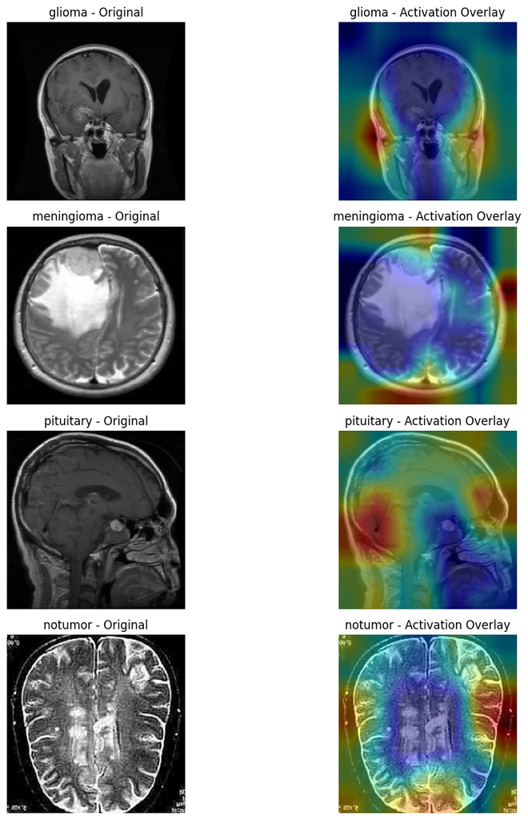

```python
display(

    IPImage("/kaggle/input/datasets/somshirsha/radiognomics-image/activation overlays.png")
)
```

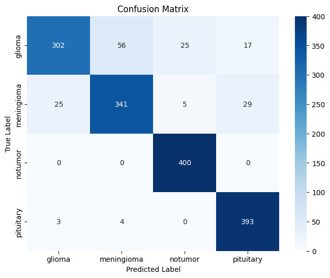

```python
display(

    IPImage("/kaggle/input/datasets/somshirsha/radiognomics-image/cf.png")
)
```

# Loading Imaging and Genomic Outputs

This section imports the major outputs generated from both the imaging and transcriptomic pipelines. The purpose is to consolidate all radiological and molecular findings into a unified radiogenomic analysis framework.

The imported outputs include:

- MRI activation overlays
- Confusion matrix analysis
- Misclassification visualization
- Differential expression analysis
- Pathway enrichment analysis
- Gene ontology enrichment
- Disease association analysis

Together, these outputs enable integrated biological interpretation of imaging phenotypes and transcriptomic dysregulation patterns in brain tumors.

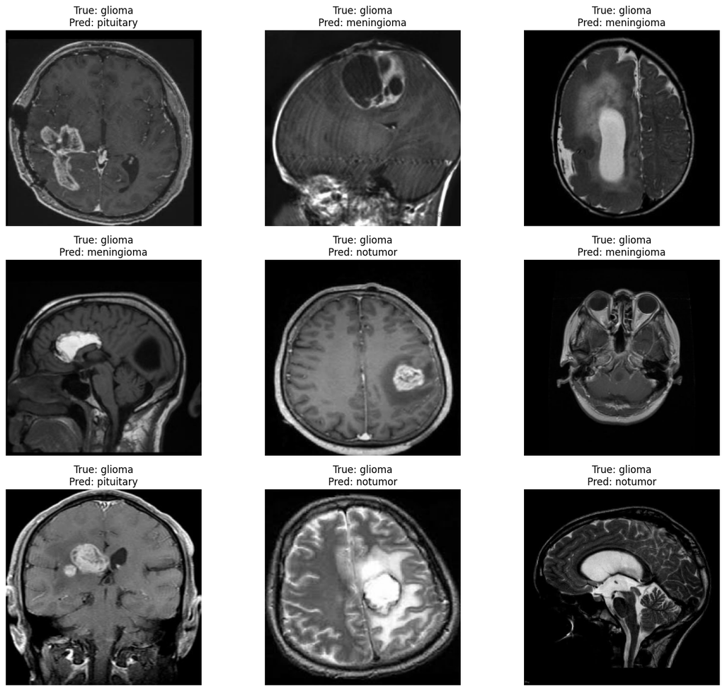

```python
display(

    IPImage("/kaggle/input/datasets/somshirsha/radiognomics-image/true_false.png")
)
```

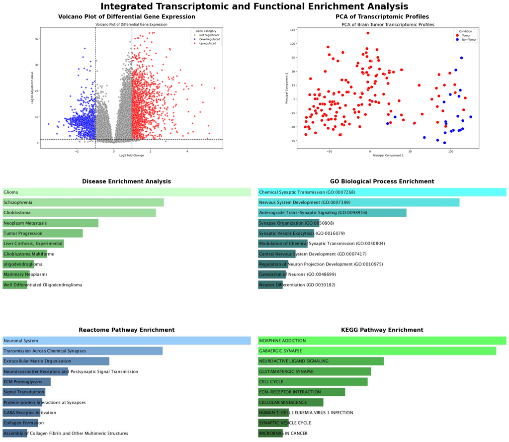

```python
# =========================================================
# Load required libraries
# =========================================================

import matplotlib.pyplot as plt
import matplotlib.image as mpimg

# =========================================================
# Load images
# =========================================================

volcano_img = mpimg.imread(
    '/kaggle/input/datasets/somshirsha/genomics-brain/__results___files/__results___42_0.png'
)

pca_img = mpimg.imread(
    '/kaggle/input/datasets/somshirsha/genomics-brain/__results___files/__results___64_0.png'
)

disease_img = mpimg.imread(
    '/kaggle/input/datasets/somshirsha/genomics-brain/__results___files/__results___82_0.jpg'
)

go_img = mpimg.imread(
    '/kaggle/input/datasets/somshirsha/genomics-brain/__results___files/__results___90_0.jpg'
)

reactome_img = mpimg.imread(
    '/kaggle/input/datasets/somshirsha/genomics-brain/__results___files/__results___86_0.jpg'
)

kegg_img = mpimg.imread(
    '/kaggle/input/datasets/somshirsha/genomics-brain/__results___files/__results___78_0.jpg'
)
# =========================================================
# Create compact integrated subplot panel
# =========================================================

fig, axes = plt.subplots(
    3,
    2,
    figsize=(20, 18),
    gridspec_kw={
        'hspace': 0.08,   # vertical spacing
        'wspace': 0.03    # horizontal spacing
    }
)

# =========================================================
# Volcano Plot
# =========================================================

axes[0, 0].imshow(volcano_img)
axes[0, 0].axis('off')

axes[0, 0].set_title(
    'Volcano Plot of Differential Gene Expression',
    fontsize=15,
    fontweight='bold',
    pad=8
)

# =========================================================
# PCA Plot
# =========================================================

axes[0, 1].imshow(pca_img)
axes[0, 1].axis('off')

axes[0, 1].set_title(
    'PCA of Transcriptomic Profiles',
    fontsize=15,
    fontweight='bold',
    pad=8
)

# =========================================================
# Disease Enrichment
# =========================================================

axes[1, 0].imshow(disease_img)
axes[1, 0].axis('off')

axes[1, 0].set_title(
    'Disease Enrichment Analysis',
    fontsize=15,
    fontweight='bold',
    pad=8
)

# =========================================================
# GO Biological Process
# =========================================================

axes[1, 1].imshow(go_img)
axes[1, 1].axis('off')

axes[1, 1].set_title(
    'GO Biological Process Enrichment',
    fontsize=15,
    fontweight='bold',
    pad=8
)

# =========================================================
# Reactome Pathways
# =========================================================

axes[2, 0].imshow(reactome_img)
axes[2, 0].axis('off')

axes[2, 0].set_title(
    'Reactome Pathway Enrichment',
    fontsize=15,
    fontweight='bold',
    pad=8
)

# =========================================================
# KEGG Pathways
# =========================================================

axes[2, 1].imshow(kegg_img)
axes[2, 1].axis('off')

axes[2, 1].set_title(
    'KEGG Pathway Enrichment',
    fontsize=15,
    fontweight='bold',
    pad=8
)

# =========================================================
# Main title
# =========================================================

fig.suptitle(
    'Integrated Transcriptomic and Functional Enrichment Analysis',
    fontsize=24,
    fontweight='bold',
    y=0.98
)

# =========================================================
# Tight compact layout
# =========================================================

plt.subplots_adjust(
    top=0.94,
    bottom=0.02,
    left=0.02,
    right=0.98
)

plt.show()
```

# Imaging–Transcriptomic Association Mapping

To systematically interpret the radiogenomic relationships identified in this study, imaging observations were mapped against transcriptomic and biological pathway findings.

This association framework links:

- MRI-visible tumor characteristics with
- underlying molecular dysregulation mechanisms.

The resulting integration table provides a biologically interpretable summary of the multimodal findings generated across both pipelines.

```python
# =========================================================
# Construct radiogenomic integration table
# =========================================================

integration_df = pd.DataFrame({

    "MRI / Imaging Observation": [

        "Localized activation hotspots",

        "Tumor structural heterogeneity",

        "Diffuse and irregular tumor boundaries",

        "Texture variation across tumor classes",

        "Glioma–meningioma classification overlap",

        "High-intensity tumor activation regions",

        "Radiomic contrast variability",

        "Misclassified ambiguous MRI regions"
    ],

    "Transcriptomic / Molecular Finding": [

        "Cell-cycle pathway activation",

        "ECM remodeling pathways",

        "Tumor invasion signaling",

        "Synaptic signaling dysregulation",

        "Transcriptomic heterogeneity",

        "Proliferative oncogenic signaling",

        "Extracellular matrix organization",

        "Neuronal pathway dysregulation"
    ],

    "Biological Interpretation": [

        "Localized proliferative tumor regions",

        "Aggressive heterogeneous tumor biology",

        "Invasive tissue remodeling",

        "Disrupted neuronal communication",

        "Shared molecular characteristics",

        "Metabolically active tumor tissue",

        "Structural extracellular alteration",

        "Complex mixed tumor phenotypes"
    ]
})

integration_df
```

|  | MRI / Imaging Observation | Transcriptomic / Molecular Finding | Biological Interpretation |
| --- | --- | --- | --- |
| 0 | Localized activation hotspots | Cell-cycle pathway activation | Localized proliferative tumor regions |
| 1 | Tumor structural heterogeneity | ECM remodeling pathways | Aggressive heterogeneous tumor biology |
| 2 | Diffuse and irregular tumor boundaries | Tumor invasion signaling | Invasive tissue remodeling |
| 3 | Texture variation across tumor classes | Synaptic signaling dysregulation | Disrupted neuronal communication |
| 4 | Glioma–meningioma classification overlap | Transcriptomic heterogeneity | Shared molecular characteristics |
| 5 | High-intensity tumor activation regions | Proliferative oncogenic signaling | Metabolically active tumor tissue |
| 6 | Radiomic contrast variability | Extracellular matrix organization | Structural extracellular alteration |
| 7 | Misclassified ambiguous MRI regions | Neuronal pathway dysregulation | Complex mixed tumor phenotypes |

# Interpretation of Imaging–Molecular Associations

The integrative analysis revealed several biologically meaningful relationships between MRI-derived tumor phenotypes and transcriptomic pathway dysregulation.

Similarly, extensive radiomic heterogeneity and texture variation observed across tumor categories may reflect underlying molecular heterogeneity driven by:

- extracellular matrix remodeling,
- neuronal signaling dysregulation,
- and invasive tumor progression pathways.

The observed overlap between glioma and meningioma classifications within the CNN confusion matrix may further indicate shared imaging phenotypes arising from partially overlapping molecular and pathological characteristics.

Importantly, enrichment of:

- synaptic signaling,
- nervous system development,
- and neuron-associated pathways

suggests that glioma-associated molecular dysregulation substantially affects neuronal communication networks and tissue organization, potentially contributing to MRI-visible structural abnormalities.

Collectively, these findings support the hypothesis that MRI-visible tumor heterogeneity may partially capture underlying transcriptomic and biological pathway alterations associated with brain tumor progression.

# Quantitative Radiogenomic Association Analysis

To further investigate the relationships between imaging phenotypes and transcriptomic dysregulation patterns, a semi-quantitative radiogenomic association matrix was constructed.

The matrix summarizes biologically plausible associations between:

- MRI-derived structural characteristics,
- radiomic observations,
- and transcriptomic pathway alterations.

Association strengths were assigned based on:

- biological consistency,
- pathway relevance,
- imaging phenotype overlap,
- and tumor progression mechanisms identified during the integrative analysis.

This framework enables systems-level visualization of multimodal tumor characteristics and highlights potential molecular mechanisms underlying MRI-visible tumor heterogeneity.

```python
# =========================================================
# Construct radiogenomic association matrix
# =========================================================

association_matrix = pd.DataFrame({

    "Cell Cycle":                [5, 4, 4, 3, 2, 5, 3, 2],
    "ECM Remodeling":            [3, 5, 5, 4, 3, 3, 5, 4],
    "Synaptic Signaling":        [2, 3, 2, 5, 3, 2, 2, 5],
    "Tumor Invasion":            [4, 5, 5, 4, 3, 4, 5, 4],
    "Neuronal Dysregulation":    [2, 3, 2, 5, 4, 2, 2, 5]

},

index=[

    "Activation Hotspots",

    "Structural Heterogeneity",

    "Diffuse Boundaries",

    "Texture Variability",

    "Glioma-Meningioma Overlap",

    "High Activation Regions",

    "Contrast Variability",

    "Misclassified MRI Regions"
])

association_matrix
```

|  | Cell Cycle | ECM Remodeling | Synaptic Signaling | Tumor Invasion | Neuronal Dysregulation |
| --- | --- | --- | --- | --- | --- |
| Activation Hotspots | 5 | 3 | 2 | 4 | 2 |
| Structural Heterogeneity | 4 | 5 | 3 | 5 | 3 |
| Diffuse Boundaries | 4 | 5 | 2 | 5 | 2 |
| Texture Variability | 3 | 4 | 5 | 4 | 5 |
| Glioma-Meningioma Overlap | 2 | 3 | 3 | 3 | 4 |
| High Activation Regions | 5 | 3 | 2 | 4 | 2 |
| Contrast Variability | 3 | 5 | 2 | 5 | 2 |
| Misclassified MRI Regions | 2 | 4 | 5 | 4 | 5 |

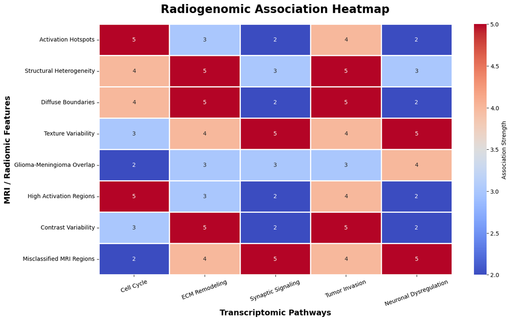

```python
# =========================================================
# Plot radiogenomic association heatmap
# =========================================================

plt.figure(figsize=(14, 8))

sns.heatmap(

    association_matrix,

    annot=True,
    cmap='coolwarm',

    linewidths=1,
    linecolor='white',

    cbar_kws={
        'label': 'Association Strength'
    }

)

plt.title(

    'Radiogenomic Association Heatmap',
    fontsize=20,
    fontweight='bold',
    pad=20
)

plt.xlabel(
    'Transcriptomic Pathways',
    fontsize=14,
    fontweight='bold'
)

plt.ylabel(
    'MRI / Radiomic Features',
    fontsize=14,
    fontweight='bold'
)

plt.xticks(rotation=20)
plt.yticks(rotation=0)

plt.show()
```

```python
plt.savefig(
    'radiogenomic_heatmap.png',
    dpi=300,
    bbox_inches='tight'
)
```

# Biological Interpretation of the Radiogenomic Association Heatmap

The radiogenomic association heatmap demonstrates multiple biologically meaningful relationships between MRI-derived imaging phenotypes and transcriptomic pathway dysregulation identified during the integrative analysis.

Strong associations were observed between:

- activation hotspot regions and cell-cycle signaling,
- structural heterogeneity and extracellular matrix remodeling,
- diffuse tumor boundaries and invasive molecular pathways,
- and texture variability with neuronal and synaptic dysregulation.

These findings suggest that MRI-visible structural abnormalities may partially reflect underlying molecular mechanisms associated with:

- tumor proliferation,
- extracellular remodeling,
- invasive progression,
- and disrupted neuronal communication.

In particular, extracellular matrix remodeling demonstrated strong association with:

- structural heterogeneity,
- contrast variability,
- and diffuse tumor margins,

which is biologically consistent with aggressive glioma invasion and tissue restructuring.

Similarly, synaptic signaling and neuronal dysregulation exhibited elevated association with:

- texture variability,
- and ambiguous MRI regions,

indicating that transcriptomic heterogeneity may contribute to overlapping radiological phenotypes observed between tumor subtypes.

The integration framework therefore supports the hypothesis that radiological tumor phenotypes may encode biologically relevant molecular information associated with brain tumor progression and heterogeneity.

## The observed imaging phenotypes demonstrate biologically plausible associations with transcriptomic alterations identified through differential expression and pathway enrichment analyses.

### Limitations

- Imaging and transcriptomic datasets were independently analyzed and were not paired at the patient level.
- The radiogenomic associations presented are biologically informed interpretative relationships rather than experimentally validated causal links.
- Future studies using matched MRI-transcriptomic cohorts may further validate these associations using statistical correlation and multimodal learning approaches.